# Dynamic Programming

## What is Dynamic Programming?

Dynamic Programming (DP) is a technique for solving complicated problems by breaking them down into *simpler subproblems*.

### This lecture we'll...

- Introduce characteristics of DP problems
- Walk through the main concepts behind DP using the Fibonacci Sequence as a basic example
- Practice implementing an algorithm to a classic DP problem

### Goals:

- Understand what optimal substructure and overlapping subproblems means
- Use memoization or tabulation to decrease runtime
- Translate a given recurrence relation into a working implementation

## What types of problems can we solve with DP?

- Optimization
  - Maximize/minimize some value given these constraints
- Combinatorial
  - How do we choose items from a set to meet certain conditions
- DP Problems have **optimal substructure** and **overlapping subproblems**

# Fibonacci Sequence

## What is the Fibonacci Sequence?

Each element in the Fibonacci Sequence is the sum of the previous two elements.

$$F(0) = 0$$$$F(1) = 1$$$$F(n) = F(n-1) + F(n-2)$$

```python
def fib(n):
    """Returns the nth Fibonacci number"""
    raise NotImplementedError("Fill this in")
```

```python
print(fib(10))
```

## What do we notice about the implementation of `fib`?

1. It's recursive!
   1. A function is recursive if the function calls itself.
   2. Each call to `fib` is smaller than the previous call --> these are "subproblems" of the original problem
   3. We use the results from the smaller subproblems to calculate the result for the larger problem

### Optimal Substructure

A problem has **optimal substructure** if the optimal solution to the problem can be constructed from the optimal solutions of the subproblems.

In otherwords, the optimal solution can be defined recursively, and the relationship between the optimal solution and the sub-solutions is the **recurrence relation**.

- What are other examples of problems with optimal substructure?
  - Shortest Path: Let's say you're trying to find the shortest path from city A to city B ($P(A, B)$). The path between any two points on $P(A,B)$ will be the shortest path between those two points.

## What else do we notice about the implementation in fib?

1. It's a pretty inefficient implementation

```python
import time

def time_fib(fib_func, n):
    start = time.time()
    end = time.time()
    print(f"{n}: {end-start}")
```

```python
for i in [5, 10, 15, 20, 25, 30, 35, 40]:
    time_fib(fib, i)
```

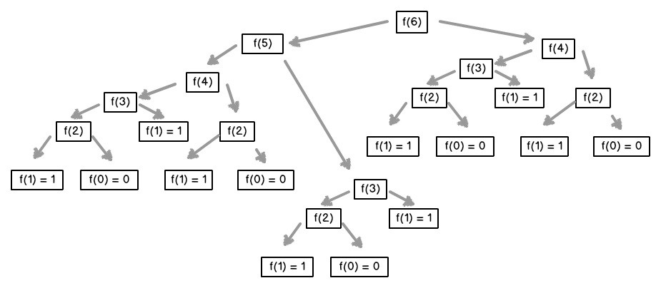

1. How many times is `fib(2)` called?
2. How many times is `fib` called in the above diagram?

## Overlapping Substructure

A problem has **overlapping substructure** if it can be broken down into subproblems which are **reused several times**

We end up doing a lot of repeat work. How can we optimize this?

## Idea 1: Memoization

Store the results to the subproblems as we go so we can access them later without recomputing.

**Key Idea:** We can use extra space to decrease the runtime (**space-time tradeoff**)

```python
memo = {}  # global cache

def fib_memo1(n):
    # Base cases
    if n == 0: return 0
    if n == 1: return 1

    # Check if the result is already in the cache and return it if present
    raise NotImplementedError("Fill this in")

    # If not, calculate the result and store it in the cache.
    solution = fib_memo1(n-1) + fib_memo1(n-2)
    raise NotImplementedError("Fill this in")

    return solution
```

```python
for i in [10, 20, 30, 40, 50]:
    time_fib(fib_memo1, i)
```

```python
# Sidenote: Python has a built in cache you can use!
import functools

@functools.lru_cache  # <-- this is called a decorator
def fib_memo2(n):
    if n == 0: return 0
    if n == 1: return 1
    return fib_memo2(n-1) + fib_memo2(n-2)
```

## Idea 2: Tabulation

Calculate and store the results to the subproblems *beforehand*, starting from `0` and working way up to `n`.

- Memoization is top-down and recursive
- Tabulation is bottom-up and iterative

```python
def fib_tab(n):
    # initialize array and fill in the "base cases"
    tab = [0 for i in range(0, n+1)]
    tab[0] = 0
    tab[1] = 1

    # Calculate and store the rest of the values
    for i in range(2, n+1):
        raise NotImplementedError("Fill this in")

    return tab[n]
```

```python
for i in [5, 10, 15, 20, 30, 50]:
    time_fib(fib_tab, i)
```

```python
# Extra credit: Fib with "sliding window"
# fib_tab currently keeps track of all previously calculated values of fib from i=0...n
# Try reducing the amount of space requires by only keeping track of the previous
# two values

def fib_tab2(n):
    raise NotImplementedError("Fill this in")
```

# Summary of Key Points

1. Problems that can be solved by DP have:
   1. **Optimal Substructure**
      1. The problem has a recurrence relationship
      2. You can use the solution to smaller subproblems to solve the overall problem.
   2. **Overlapping Subproblems**
      1. Can reduce computation time by using extra space to store the intermediate results
   3. Approaches for implementing DP algorithms:
      1. **Memoization** (recursive, top-down)
      2. **Tabulation** (iterative, bottom-up)

## Example: Weighted Interval Scheduling

We have a set of jobs. Each job has a **start time** `job.start`, an **end time** `job.end` (`job.start < job.end`) and a **value** or profit associated with it `job.value`. Two jobs are **compatible** if they don't overlap. We want to find the subset of compatible jobs with the **maximum value**

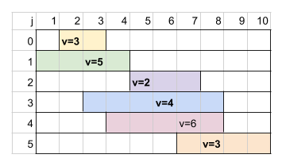

e.g., I'm a freelancer trying to schedule my next ten weeks. I'm considering a set of gigs that have set start/end times and will pay me certain amounts. I can only take one gig at once. How do I maximize how much I can earn?

### Example: Weighted Interval Scheduling

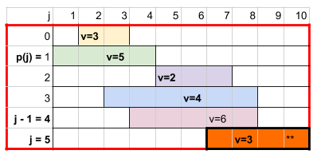

- The red box indicates the scope of the current problem we're considering.
- Sort the jobs by increasing finish time. Consider each job in reverse order, starting with the last job.
- Let's say we're looking at the $j$th job. We can either include it or not include it.

### Option 1: Include the job

If we include job $j$, we can only consider including other jobs that finish before job $j$ starts.

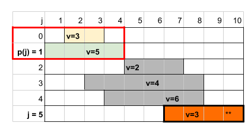

- Let's define $p(j)$ as the index of the last job that finishes before job $j$ starts.
- The optimal value for this solution is the value of the current job ($jobs[j].value$) plus the optimal solution for jobs from $0...p(j)$

### Option 2: Exclude the job

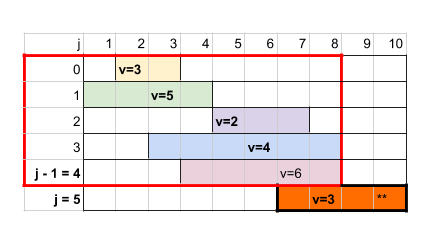

The optimal value is the optimal solution for jobs from $0...j - 1$.

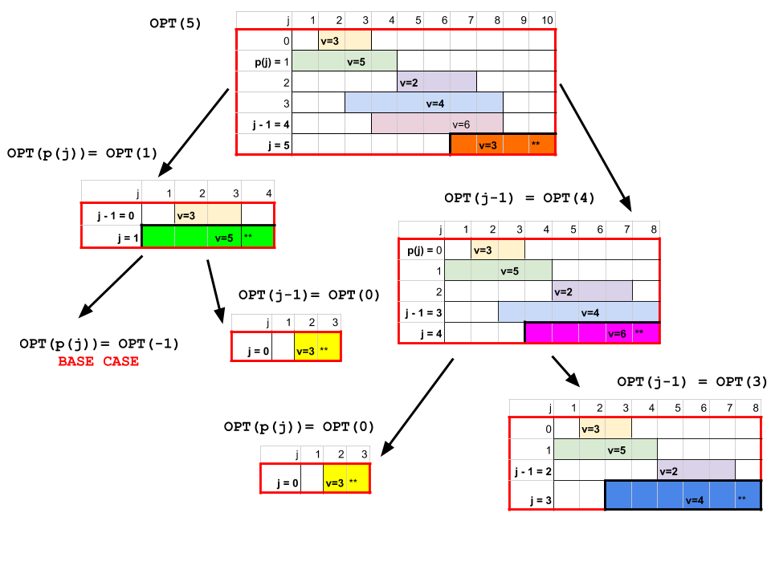

### Recurrence relationship

- Jobs are labeled from $j = 0...n$ in order of increasing finish time.
  - We use $j$ to index into the given list of jobs.
- $OPT(j)$ is the optimal solution to the problem consider jobs from $0...j$.
  - Base case is when we are considering 0 jobs, which means we can have 0 value. $OPT(-1) = 0$
- $p(j)$ is the index of the last job that finishes before job $j$ starts
  - `jobs[p(j)].finish <= jobs[j].start`
  - $p(j) = -1$ if there is no job that finishes before $j$ starts
  - $p(j) < j$

$$OPT(-1) = 0$$$$OPT(j) = \max (jobs[j].value + OPT(p(j), OPT(j-1))$$

```python
from collections import namedtuple
from typing import List, Tuple, Dict

Job = namedtuple('Job', 'start, end, value')


# Extra: What's the current run time for this implementation? Is there a way we could decrease the run time?
def get_previous_jobs(jobs: List[Job], job_index: int):
    """
    Given a list of jobs and a job, returns the index of the last job that finishes before the given job starts.
    Returns -1 if there are no non-overlapping previous jobs
    """
    current_job = jobs[job_index]

    for i in range(job_index - 1, -1, -1):  # Iterate through jobs backwards
        prev_job = jobs[i]
        if prev_job.end <= current_job.start:
            return i
    return -1
```

```python
def weighted_intervals(jobs: List[Job]) -> int:
    """ Given a list of jobs with weights, returns the maximum possible value from a subset of compatible jobs."""
    def _weighted_intervals(current_job_index: int) -> int:
        """Helper function that takes current_job_index (j) to index into the list of jobs"""
        # Base case: OPT(-1) = 0
        if current_job_index == -1:
            return 0

        # Option 1: include the last job
        # get jobs that finish before current job: p(j)
        previous_jobs_index = get_previous_jobs(jobs, current_job_index)

        # solve subproblem: OPT(p(j))
        raise NotImplementedError("Uncomment the below line and fill it in")
        # subproblem_value = ???

        # use result from subproblem to calculate overall solution: jobs[j].value + OPT(p(j))
        include_value = jobs[current_job_index].value + subproblem_value

        # Option 2: exclude the last job
        # solve subproblem: OPT(j-1)
        raise NotImplementedError("Uncomment the below line and fill it in")
        # exclude_value = ???

        # Choose the maximum of the two options
        return max(include_value, exclude_value)

    return _weighted_intervals(len(jobs) - 1)
```

```python
jobs = [
    Job(1, 3, 2),
    Job(0, 5, 5),
    Job(2, 5, 8),
    Job(3, 6, 5),
    Job(5, 8, 3),
    Job(6, 10, 1)
]

print(weighted_intervals(jobs))
```

- Notice we haven't added memoization or tabulation yet.
  - How many times do we end up calling `_weighted_intervals(0)`?

### Implementation: Extensions and Next Steps

- How would you implement this with tabulation?
- Right now we're only returning the value of optimum solution. How would you return the actual subset of jobs as well?

```python
def weighted_intervals_tab(jobs):
    """ Given a list of jobs with weights, returns the subset of jobs that maximizes the value of the jobs."""

    # Fill in max_value to contain the maximum value from the set of jobs from 0...i
    max_value = [0 for _ in jobs]

    for current_job_index, job in enumerate(jobs):
        # Option 1: Include the job
        # get jobs that finish before current job: p(j)
        previous_job_index = get_previous_jobs(jobs, current_job_index)

        # Get the solution to the subproblem
        if previous_job_index == -1:
            # No previous jobs finish before current job starts. Base case
            raise NotImplementedError("Uncomment the below line and fill it in")
            # subproblem_value = ???
        else:
            # OPT(p(j))
            raise NotImplementedError("Uncomment the below line and fill it in")
            # subproblem_value = ???

        # use result from subproblem to calculate overall solution: jobs[j].value + OPT(p(j))
        include_value = subproblem_value + job.value

        # Option 2: Exclude the job
        if current_job_index == 0:
            # j-1 would be -1. Base case
            raise NotImplementedError("Uncomment the below line and fill it in")
            # exclude_value = ???
        else:
            # Get the solution to subproblem: OPT(j-1)
            raise NotImplementedError("Uncomment the below line and fill it in")
            # exclude_value = ???

        # Choose the maximum of the two options
        raise NotImplementedError

    return max_value[-1]  # Return solution to the overall problem

print(weighted_intervals_tab(jobs))
```

## Summary

- Why talk about DP?
- You probably won't be coming up with new DP algorithms every day, but
  - DP algorithms have applications across industries and in many tools you use daily.
  - The core concepts of DP are important to understand in computer science.

### DP in Real Life

- Shortest Path: Bellman-Ford
  - Network routing
- Longest Common Subsequence
  - DNA Sequence Alignment
  - Document diffing (`git diff`)
- E-commerce: [Calculating dicount offers](https://medium.com/myntra-engineering/discount-offers-using-dynamic-programming-ba383098c628)
  - Each item has an original sticker price and a discount associated with it (e.g., 20% off an original sticker price of $50).
  - Each item can also be part of a Buy One Get One Free offer, where you can combine pairs of items and get the one with the lower original sticker price for free.
  - You cannot apply an item's discount if you're also using it as part of a BOGO deal.
  - How do you optimally apply the available discounts to maximize your savings?

### DP in YOUR life

- Optimal Substructure
  - Recursion is everywhere in computer science.
    - Trees, XML, File systems
    - Linked lists
    - Sorting and searching
  - It's also a popular topic for SWE interviews
- Overlapping Subproblems
  - Space-Time tradeoff: memoize or tabulate
  - Memoization is a form of caching
  - If your program is really slow, ask if there's repeat work being done and if you can store intermediate results somewhere